# Индивидуалный проект

Этап 2

Мулин И.

Российский университет дружбы народов, Москва, Россия

9 марта 2023

# Информация

## Докладчик

- Мулин Иван Владимирович
- студент-первокурсник
- всё ещё по-прежнему студент
- Математический институт им. Никольского
- https://github.com/ivmulin

# Вводная часть

## Цели и задачи

Цель данной работы - добавить на личный сайт персональную информацию и написать пробный пост.

# Ход работы

## Предварительная настройка

Чтобы видеть изменения в реальном времени, мы, находясь в директории персонального сайта, ввели команду

```bash
~/bin/hugo server
```

## Предварительная настройка

В конце вывода она напечатала в консоль адрес запущенного локального сервера:

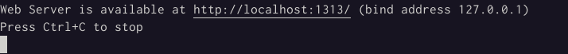

Локальный сервер

Копируя его и вставляя в строку поиска браузера, мы попадаем на локальный сервер. При любом сохранённом изменении он перезагрузит своё содержимое, что крайне удобно.

## Добавление информации о себе

Редактируя файл `content/authors/admin/_index.md`, мы изменили информацию о себе. Заменяя файл `content/authors/admin/avatar.jpg` на любое другое изображение с названием *avatar*, мы смогли изменить персональное фото:

[figure not shown]

Изменение персональной информации

## Добавление первого поста

Далее мы скопировали папку `post/getting-started` с любым другим именем (в моём случае это `post/Week 0`). Далее поменяли изображение `post/Week 0/featured.jpg` на любое другое (важно, чтобы оно нзывалось *featured*) и файл `post/Week 0/_index.jpg`:

[figure not shown]

Первый пост

## Добавление второго поста

Аналогичной процедурой создали второй пост о системе контроля версий Git:

[figure not shown]

Второй пост

# Результаты

## Заключение

Цель работы была достигнута: в результате выполнения данной работы была добавлена личная информация и написаны два тестовых поста.